# Aplicação Psicobiologia

# Nosso segundo modelo misto

Podemos ir em frente e encaixar um novo modelo, que leve em conta tanto as diferenças entre as cadeias de montanhas quanto as diferenças entre os locais dentro dessas cadeias montanhosas

```r
modelomis2<- lme(fixed= Pontuacao~ ComprimentoCorpo, random= ~1|Montanha/Local, data=condor)
summary(modelomis2)
```

```
## Linear mixed-effects model fit by REML
##  Data: condor
##        AIC      BIC   logLik
##   3985.961 4006.809 -1987.98
##
## Random effects:
##  Formula: ~1 | Montanha
##         (Intercept)
## StdDev:    18.09866
##
##  Formula: ~1 | Local %in% Montanha
##         (Intercept) Residual
## StdDev:    4.805294 14.44228
##
## Fixed effects: Pontuacao ~ ComprimentoCorpo
##                     Value Std.Error  DF  t-value p-value
## (Intercept)      40.06666 21.863732 455 1.832563  0.0675
## ComprimentoCorpo  0.05126  0.103682 455 0.494389  0.6213
##  Correlation:
##                  (Intr)
## ComprimentoCorpo -0.955
##
## Standardized Within-Group Residuals:
##         Min          Q1         Med          Q3         Max
## -3.24252518 -0.67517429 -0.01165957  0.69736451  2.88120515
##
## Number of Observations: 480
## Number of Groups:
##            Montanha Local %in% Montanha
##                   8                  24
```

Nossa questão se ajusta novamente: existe uma associação entre o comprimento do corpo e a inteligência nos condores após o controle da variação nas montanhosas e locais dentro das cadeias montanhosas?

Aqui, estamos tentando explicar todas as influências de nível de montanha e todas as influências de nível local e esperamos que nossos efeitos aleatórios tenham absorvido todas essas influências para que possamos controlá-las no modelo.

Vamos traçar isso de novo visualizar o que está acontecendo é sempre útil. Você deve ser capaz de ver oito cadeias de montanhas com três locais (diferentes pontos de cor) dentro delas, com uma linha ajustada em cada local.

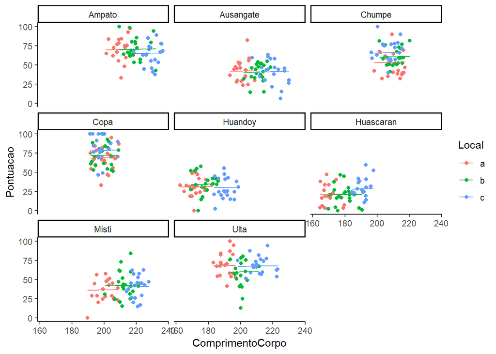

```r
ggplot(condor, aes(x = ComprimentoCorpo, y = Pontuacao, colour = Local)) +
  facet_wrap(~Montanha, nrow=3) + geom_point() + theme_classic() +
  geom_line(data = cbind(condor, pred = predict(modelomis2)), aes(y = pred)) +
  theme()
```

## Bem feito por chegar aqui!

Agora você viu que a falha em explicar a correlação nos dados poderia levar a resultados enganosos parecia que a comprimento do corpo afetava a pontuação do teste até que explicássemos a variação proveniente das cadeias de montanhas.Podemos ver agora que o comprimento do corpo não influencia os resultados dos testes

ótimo! Podemos escolher Condores menores para qualquer treinamento futuro os menores devem ser mais gerenciáveis